# IBSM-40 Monocytes integration & clustering with SCTransform

Zuly

2023-11-15

## **Experimental details**:

**Design:** cohort of individuals/donors= 4 - A,B,C,D

**Timepoints:** 4 - Day0, Day8, Day16 and Day36

**Celltypes:** 3 - Tfh, Monocytes, GammaDelta Tcells

**Sequencing strategy:**

RawData_Folder: 20220318_BoyleNextSeq MultiAnalysis_Folder: scRNA_April_2022 Chemestry= 3’ Flowcells=3 FlowcellsName = 220314-AHWM72BGXK ,220315- AHMTHYBGXL, 220316-AHLTV5BGXL Lanes=4 SamplesPerLane= Lane1=Day0, Donors=A-D; Lane2=Day8, Donors=A-D; Lane3=Day16, Donors=A-D; Lane1=Day36, Donors=A-D.

Raw data was imported from cellranger aggr output. Due to poor quality day 16 was removed from the analysis. For more information check Monocytes_with_D16data/

## **Input data**

Using the rds file produce in the data_exploration_rds0.R script

```r
ibsm.mono.F <- readRDS(file = "D:/OneDrive - Burnet Institute/Seurat_analysis_test/IBSM_40/data/IBSM_mono_filtered_210823.rds")

##Check number of cells
table(ibsm.mono.F@meta.data$day)
```

[output not shown]

## **Integration & normalization:**

*SCTransform*: This normalisation method, removes technical variability using Pearson residuals from “regularized negative binomial regression,” where cellular sequencing depth is utilized as a covariate in a generalized linear model. Data was also tested using the LogNormalisation method (Gene counts for each cell are divided by the total counts for that cell and multiplied by the scale factor. This is then natural-log transformed using log1p)

```r
#adjust the limit for allowable object sizes within R
options(future.globals.maxSize = 4000 * 1024^2)

# splitting the RNA measurements into layers for each group. Day and donor samples
split_seurat <- SplitObject(ibsm.mono.F, split.by = "day_donor")

split_seurat <- split_seurat[c("day0_donor0", "day0_donor1", "day0_donor2", "day0_donor3","day8_donor0", "day8_donor1","day8_donor2", "day8_donor3","day36_donor0", "day36_donor1", "day36_donor2", "day36_donor3")]

for (i in 1:length(split_seurat)) {
   split_seurat[[i]] <- SCTransform(split_seurat[[i]], vars.to.regress = c("percent.mt"))
}

# Check which assays are stored in objects
split_seurat$day0_donor0@assays

# Select the most variable features to use for integration
integ_features <- SelectIntegrationFeatures(object.list = split_seurat,
                                            nfeatures = 3000)

# Prepare the SCT list object for integration
split_seurat <- PrepSCTIntegration(object.list = split_seurat,
                                   anchor.features = integ_features)

# Find best buddies - can take a while to run
integ_anchors <- FindIntegrationAnchors(object.list = split_seurat,
                                        normalization.method = "SCT",
                                        anchor.features = integ_features)
# Integrate across conditions
immune.combined <- IntegrateData(anchorset = integ_anchors,
                                   normalization.method = "SCT")
```

## **Continue standard workflow:**

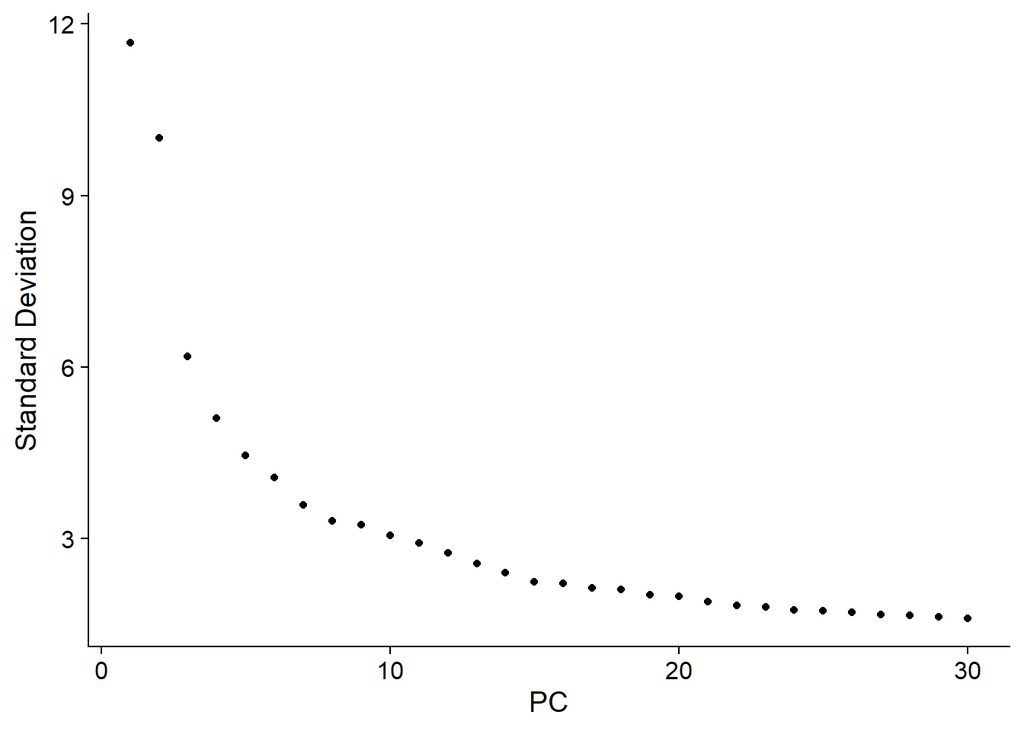

```r
##Performing an integrated analysis

# specify that we will perform downstream analysis on the corrected data note that the
# original unmodified data still resides in the 'RNA' assay
# normalised data resides in the 'SCT" assay slot (used for DE analysis)
DefaultAssay(immune.combined) <- "integrated"

# Run the standard workflow for visualization and clustering
immune.combined <- RunPCA(immune.combined, npcs = 30, verbose = FALSE)
ElbowPlot(immune.combined, ndims = 30)
```

```r
immune.combined <- RunUMAP(immune.combined, reduction = "pca", dims = 1:20)
immune.combined <- FindNeighbors(immune.combined, reduction = "pca", dims = 1:20)

##Fixing levels of some variables
day_levels <- c("day0", "day8", "day36")
immune.combined@meta.data$day <- factor(x = immune.combined@meta.data$day, levels = day_levels)
day_donor_levels <- c("day0_donor0", "day0_donor1", "day0_donor2", "day0_donor3","day8_donor0", "day8_donor1","day8_donor2", "day8_donor3","day36_donor0", "day36_donor1", "day36_donor2", "day36_donor3")
immune.combined@meta.data$day_donor <- factor(x = immune.combined@meta.data$day_donor, levels = day_donor_levels)
donor_levels <- c("donor0", "donor1","donor2","donor3")
immune.combined@meta.data$donor_id <- factor(x = immune.combined@meta.data$donor_id, levels = donor_levels)
```

Selecting PC numbers using ElbowPlot outcome:

```r
# Determine percent of variation associated with each PC
pct <- immune.combined[["pca"]]@stdev / sum(immune.combined[["pca"]]@stdev) * 100
# Calculate cumulative percents for each PC
cumu <- cumsum(pct)
# Determine which PC exhibits cumulative percent greater than 90% and % variation associated with the PC as less than 5
co1 <- which(cumu > 90 & pct < 5)[1]
co1
```

```
## [1] 25
```

```r
# Determine the difference between variation of PC and subsequent PC
co2 <- sort(which((pct[1:length(pct) - 1] - pct[2:length(pct)]) > 0.1), decreasing = T)[1] + 1
# last point where change of % of variation is more than 0.1%.
co2
```

```
## [1] 15
```

```r
# Minimum of the two calculation
pcs <- min(co1, co2)
pcs
```

```
## [1] 15
```

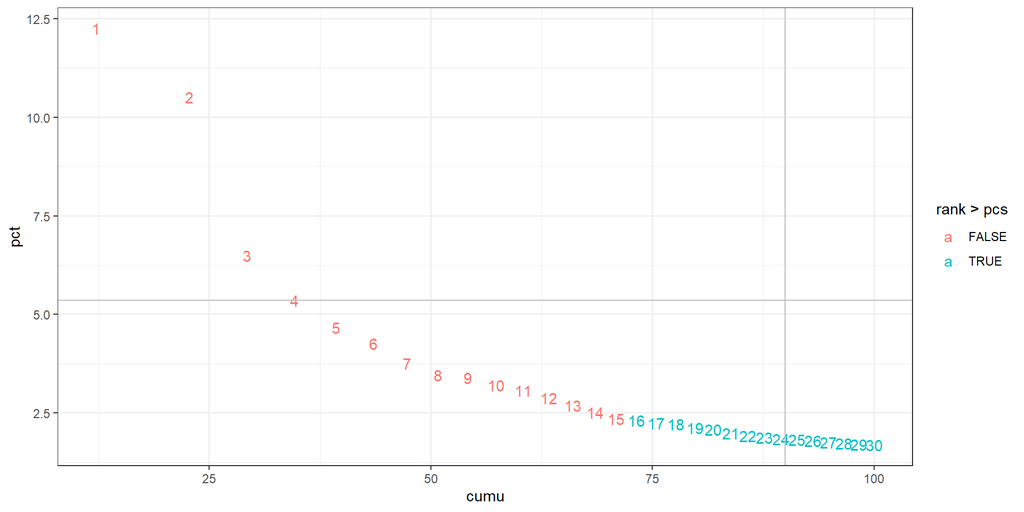

```r
# Create a dataframe with values
plot_df <- data.frame(pct = pct,
                      cumu = cumu,
                      rank = 1:length(pct))
# Elbow plot to visualize
ggplot(plot_df, aes(cumu, pct, label = rank, color = rank > pcs)) +
  geom_text() +
  geom_vline(xintercept = 90, color = "grey") +
  geom_hline(yintercept = min(pct[pct > 5]), color = "grey") +
  theme_bw()
```

*The minimum number of PC to use is 15, we will use 20.*

## **Clustering the cells:**

Graph-based clustering approach using the distance metric previously identified (i.e. Number of PCs using Elbowplot) Algorithm for modularity optimization (1 = original Louvain algorithm; 2 = Louvain algorithm with multilevel refinement; 3 = SLM ##algorithm; 4 = Leiden algorithm). Leiden requires the leidenalg python.

```r
immune.combined <- FindClusters(immune.combined, algorithm = 3, resolution = c(0.1,0.2,0.3,0.4,0.5,0.6,0.7,0.8,0.9,1.0,1.1), verbose = TRUE)
```

### **Cluster tree**

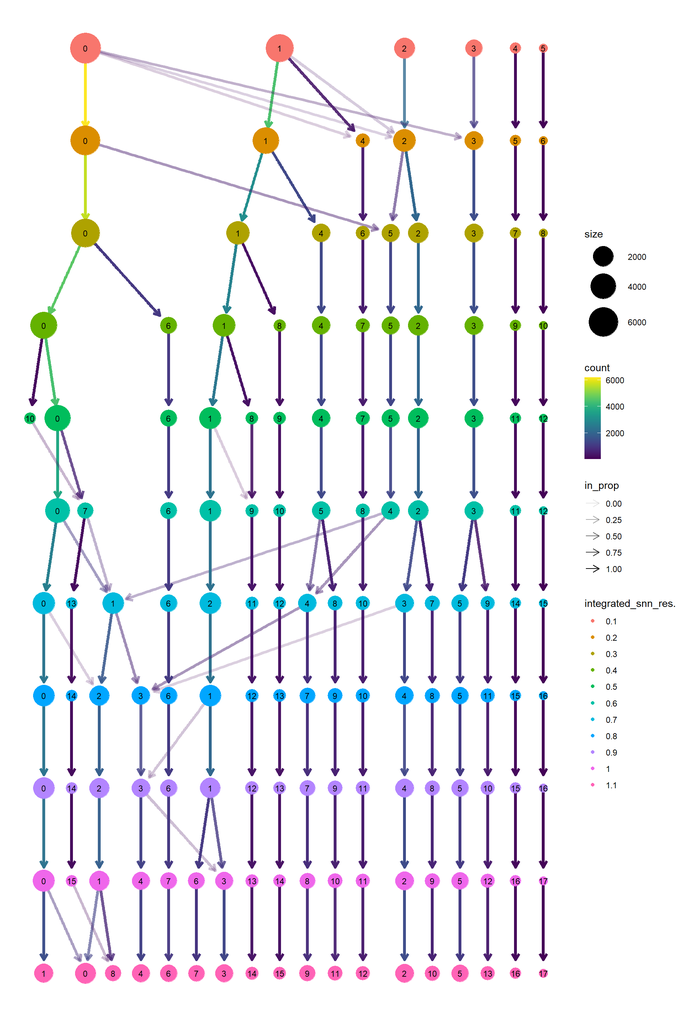

```r
clustree(immune.combined, prefix = "integrated_snn_res.", layout = "sugiyama")
```

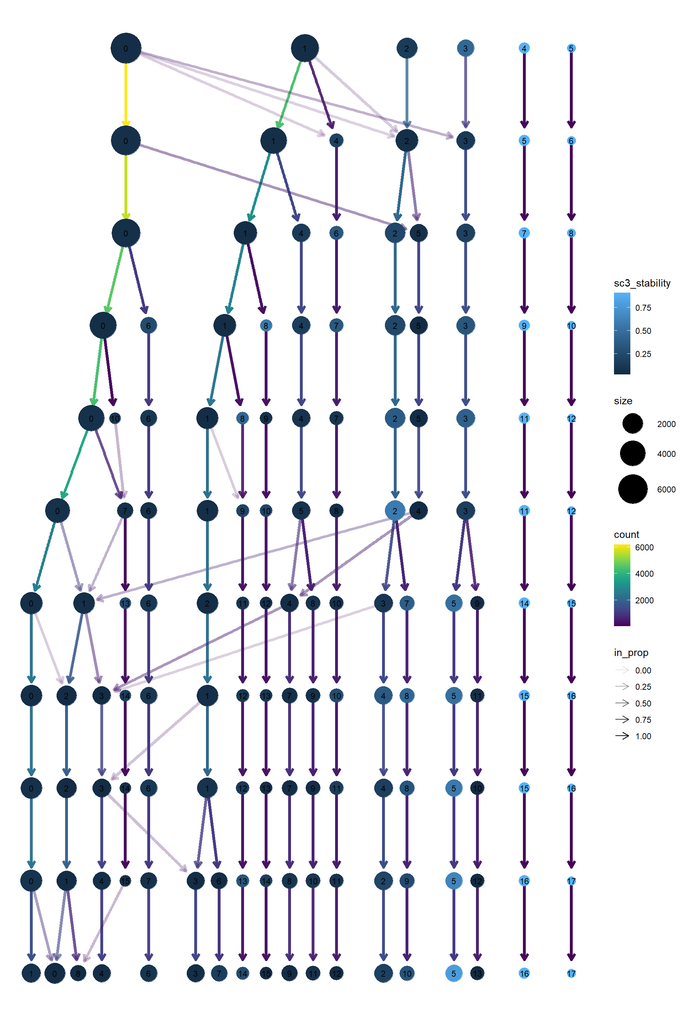

```r
clustree(immune.combined, prefix = "integrated_snn_res.", node_colour = "sc3_stability")
```

Based on the nodes origin and trajectory, the number of clusters seems to stabilize between resolution 0.8 and 0.9. (17 clusters in each)

*We inspected resolutions -0.1-1.1 finding **0.8** as optimal based on cluster tree.*

```r
Idents(immune.combined) <- "integrated_snn_res.0.8"
```

## **Clusters inspection:**

We check on the integrity of each cluster based on variables such as nFeature, nCount and content of mithocondrial transcripts. We then check the distribution of these clusters among days and donors to make sure they are evenly represented.

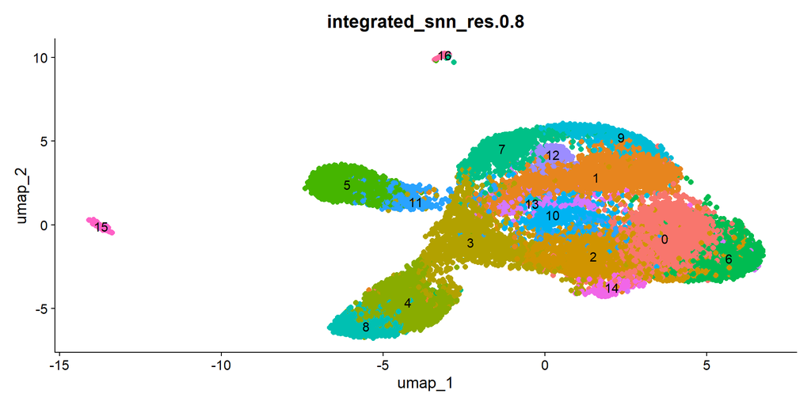

```r
##How clusters look
DimPlot(immune.combined, label = TRUE, pt.size = 2, group.by = "integrated_snn_res.0.8") + NoLegend()
```

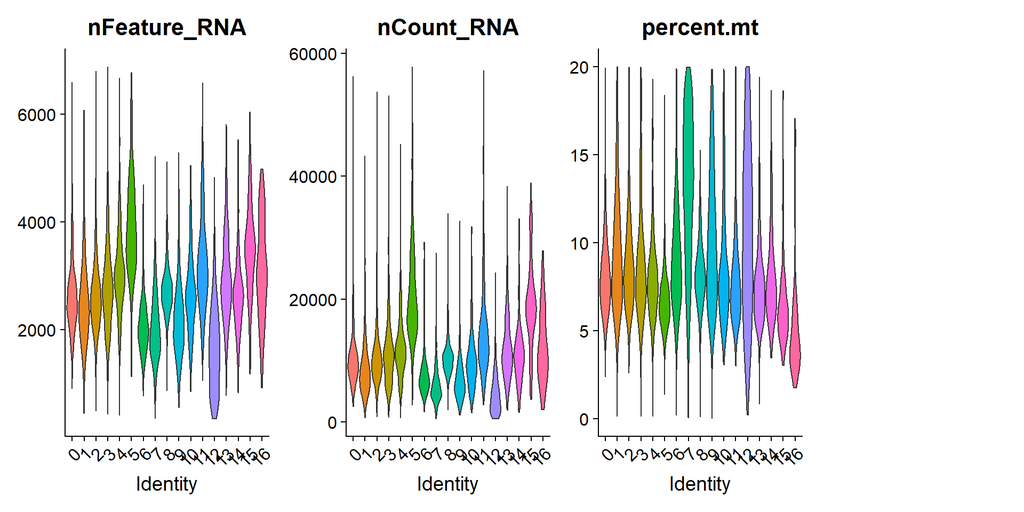

```r
##Quality of cells in clusters
VlnPlot(immune.combined, features = c("nFeature_RNA", "nCount_RNA", "percent.mt"), group.by = "integrated_snn_res.0.8", pt.size = 0, ncol = 4)
```

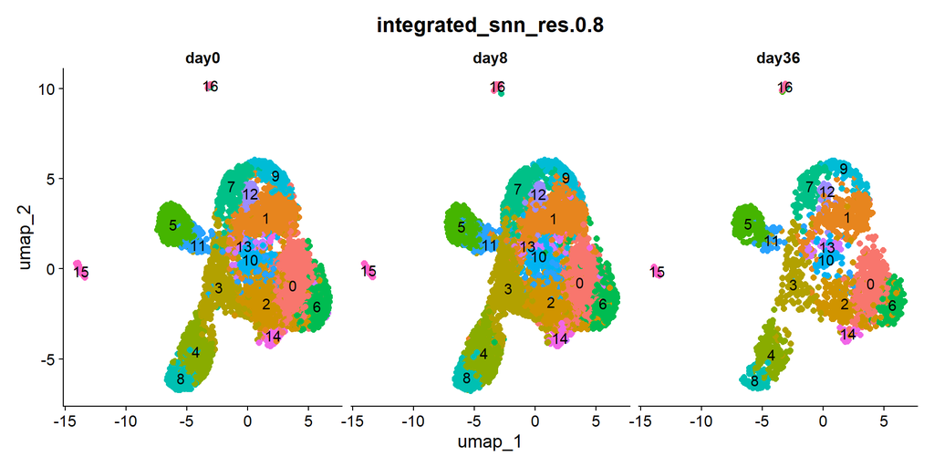

```r
##How clusters look per day
DimPlot(immune.combined, label = TRUE, pt.size = 2, group.by = "integrated_snn_res.0.8", split.by = "day") + NoLegend()
```

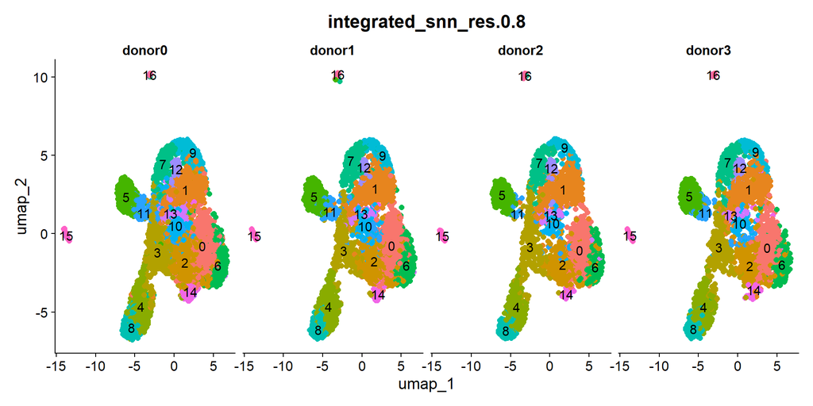

```r
##How clusters look per donor
DimPlot(immune.combined, label = TRUE, pt.size = 2, group.by = "integrated_snn_res.0.8", split.by = "donor_id") + NoLegend()
```

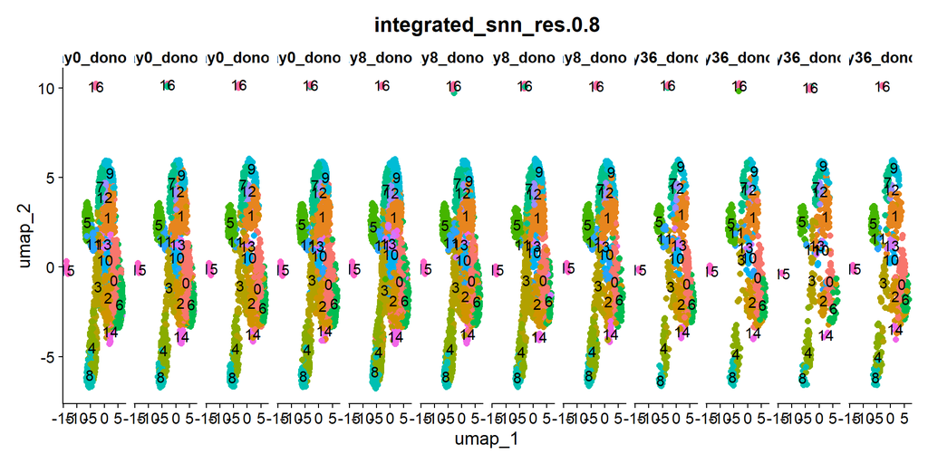

```r
##Clusters per day_donor
DimPlot(immune.combined, label = TRUE, pt.size = 2, group.by = "integrated_snn_res.0.8", split.by = "day_donor") + NoLegend()
```

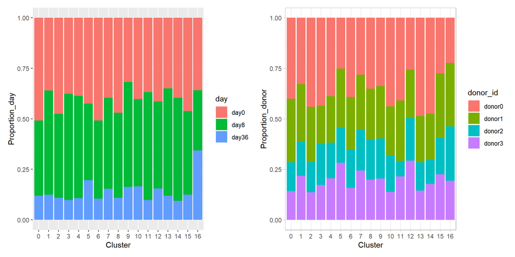

```r
#Proportion of donor and day per cluster
meta <- immune.combined@meta.data

p <- ggplot(data = meta, aes(x = integrated_snn_res.0.8, fill = day)) +
  geom_bar(position = "fill") +
  ylab("Proportion_day") + xlab("Cluster")

d <- ggplot(data = meta, aes(x = integrated_snn_res.0.8, fill = donor_id)) +
  geom_bar(position = "fill") +
  ylab("Proportion_donor") + xlab("Cluster")

p + d + theme_light()
```

## **Cluster’s ID**

We need to change the assay and run the standard workflow first.

```r
DefaultAssay(immune.combined) <- "SCT"
immune.combined <- SCTransform(immune.combined, vars.to.regress = "percent.mt", verbose = FALSE)
immune.combined <- RunPCA(immune.combined, features = VariableFeatures(object = immune.combined), npcs = 30, verbose = FALSE)
immune.combined <- RunUMAP(immune.combined, reduction = "pca", dims = 1:20)
immune.combined <- FindNeighbors(immune.combined, reduction = "pca", dims = 1:20)
```

We used two approaches to identify the clusters ID. First, we used traditional markers to identify main cell types (DCs, pDCs etc) and then, we ran FindAllmarkers to identify genes deferentially expressed among similar celltypes. (i.e. CD14+CD16- monocytes)

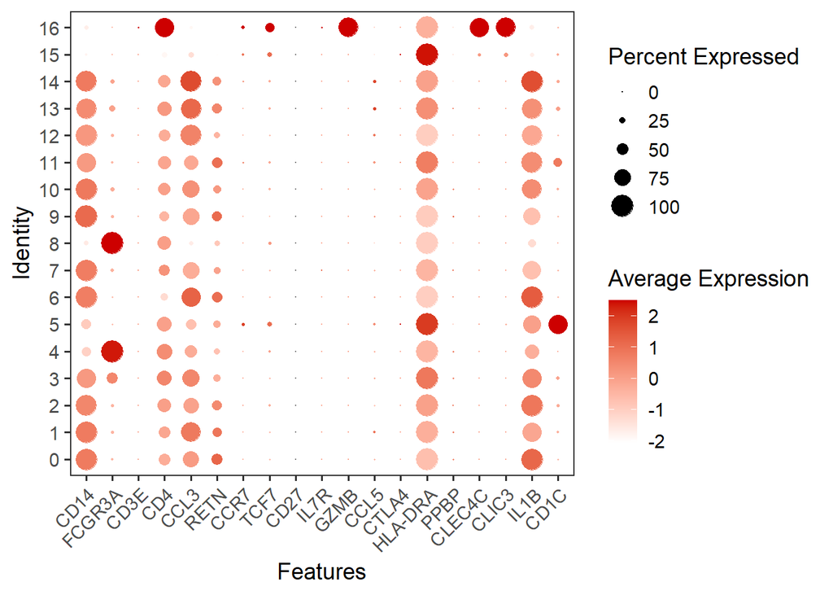

```r
DotPlot(immune.combined, assay = "SCT", features=c("CD14", "FCGR3A", "CD3E","CD4", "CCL3", "RETN", "CD8A", "CCR7", "TCF7", "CD27", "IL7R", "GZMA", "GZMB","CCL5","FOXP3", "CTLA4", "HLA-DRA", "PPBP", "CLEC4C", "CLIC3","IL1B", "CD1C"), cols=c("white", "red3"))+theme_bw(base_size=14)+theme(axis.text.x = element_text(angle = 45,  vjust = 1, hjust=1))+theme (panel.grid.major = element_blank (), panel.grid.minor = element_blank ())
```

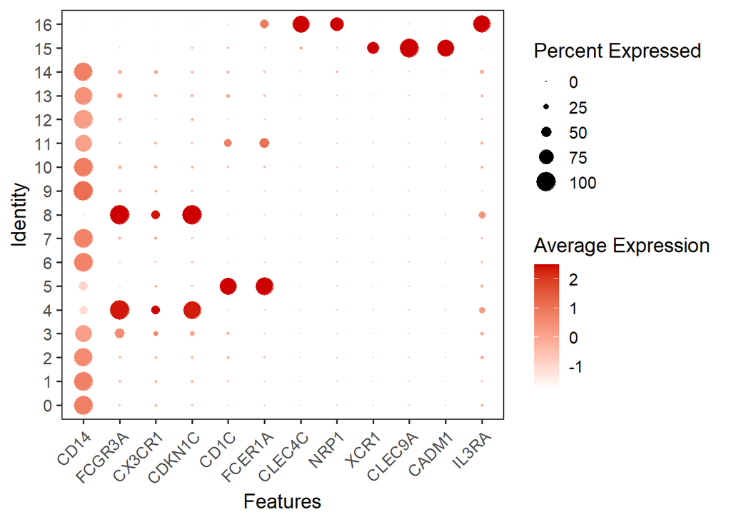

```r
DotPlot(immune.combined, assay = "SCT", features=c("CD14", "FCGR3A", "CX3CR1", "CDKN1C", "CD1C", "FCER1A", "CLEC4C", "NRP1","XCR1", "CLEC9A","CADM1","IL3RA"),
          cols=c("white", "red3"))+theme_bw(base_size=14)+theme(axis.text.x = element_text(angle = 45,  vjust = 1, hjust=1))+theme (panel.grid.major = element_blank (), panel.grid.minor = element_blank ())
```

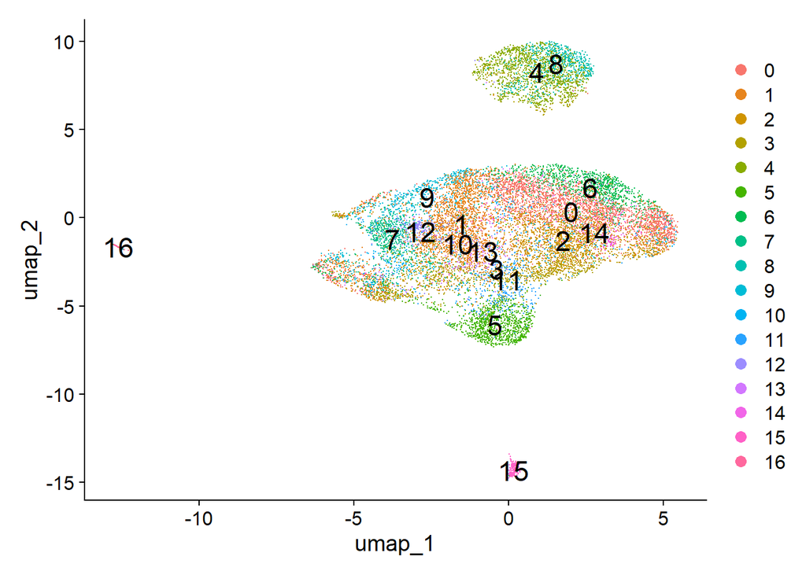

```r
DimPlot(immune.combined, reduction = "umap", label = TRUE, label.size = 6)
```

### Main clusters labels:

- Clusters 0, 1, 2, 6, 7, 9, 10, 11, 12,13 and 14 = classical monocytes
- Cluster 3 = Intermediate monocytes (CD14+, FCGR3A+, IL3RA)
- Cluster 4 and 8 = Non-classical monocytes (FCGR3A, CX3CR1, CDKN1C)
- Cluster 5 = DCs (Dendritic cells 2) (CD1C+,FCER1A+)
- Cluster 15 = DCs1 (Dendritic cells 1) (XCR1+,CLEC9A+,CADM1+)
- Cluster 16 = pDCs (Plasmacytoids cells) (CLEC4C+, NRP1+,IL3RA+)

Looking at discerning markers for classical monocytes

```r
#This step takes a long time. To make it run faster I'm just reading the csv file.
#cluster_markers <- FindAllMarkers(immune.combined)
cluster_markers <- read.csv(file = "D:/OneDrive - Burnet Institute/Seurat_analysis_test/IBSM_40/graphs/clustersSCTintdaydonor/clustersmarkers.csv")
tapply(cluster_markers$gene, cluster_markers$cluster, head)
#write.csv(cluster_markers, file = "graphs/clustersSCTintdaydonor/clustersmarkers.csv")
```

### **Classical monocytes labels:**

**Note** We found a large number of classical monocyte subcluster that look genuine. However, for pseudobulk RNA seq, each sample (cluster_day_donor) requires a min number of cells. With higher number of cluster the amount of cells decreases. We tried to reduce the number of clusters to make sure there are enough cells per samples.

We look the amount of genes shared by clusters using an upset plot

```r
##Plotting similar genes between clusters using upset plot
upset0 <-  cluster_markers
upset0$clusterid <- factor(upset0$cluster,levels=c("0", "1", "2", "3", "4", "5", "6", "7", "8", "9", "10", "11", "12","13", "14", "15", "16"),
                           labels=c("cMonocyte-IL1B_0","cMonocyte-COQ7_1",
                                    "cMonocyte-CDKN1A_2","intMonocyte_3",
                                    "ncMonocyte-CD16_4", "DCs2_5",
                                    "cMonocyte-DUSP1_6", "cMonocyte-MALAT_7",
                                    "ncMonocyte-CD16_8", "cMonocyte-S100A8_9",
                                    "cMonocyte-ISG15_10","cMonocyte-RPS18_11",
                                    "cMonocyte-mixed_12","cMonocyte-HLA_13",
                                    "cMonocyte-IL1RN_14", "DCs1_15", "pDCs_16"))

upset1 <- upset0
##Creating new grouping variables
upset1$dir <- NA
upset1$dir[upset1$avg_log2FC>0] <- "up"
upset1$dir[upset1$avg_log2FC<0] <- "dw"
tapply(upset1$avg_log2FC, upset1$dir, summary)
```

```
## $dw
##    Min. 1st Qu.  Median    Mean 3rd Qu.    Max.
## -8.4806 -1.1073 -0.6326 -0.9127 -0.3674 -0.1000
##
## $up
##    Min. 1st Qu.  Median    Mean 3rd Qu.    Max.
##  0.1000  0.3532  0.6144  0.8978  1.0541 14.6127
```

```r
##selecting only up genes
upset1 <- upset1[(upset1$dir[]=="up"),]
tapply(upset1$avg_log2FC, upset1$dir, summary)
```

```
## $up
##    Min. 1st Qu.  Median    Mean 3rd Qu.    Max.
##  0.1000  0.3532  0.6144  0.8978  1.0541 14.6127
```

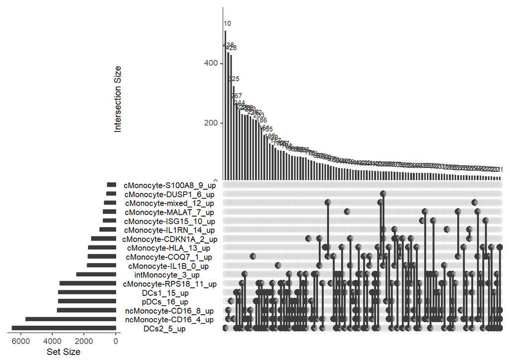

```r
upset1$cluster_dir <- NA
upset1$cluster_dir <- paste0(upset1$clusterid,"_",upset1$dir)

##creating lists of the sets
upset2 <- upset1[,c(8,11)]

upset2Split = split(upset2[,1], f = upset2$cluster_dir)

##Upset plot ordering by set frequency
upset(fromList(upset2Split),
      nsets = 17,
      nintersects = 100,
      order.by = "freq",
      decreasing = T,
      mb.ratio = c(0.5, 0.5),
      number.angles = 0,
      text.scale = 1.1,
      point.size = 2.8,
      line.size = 1)
```

### Labelling clusters

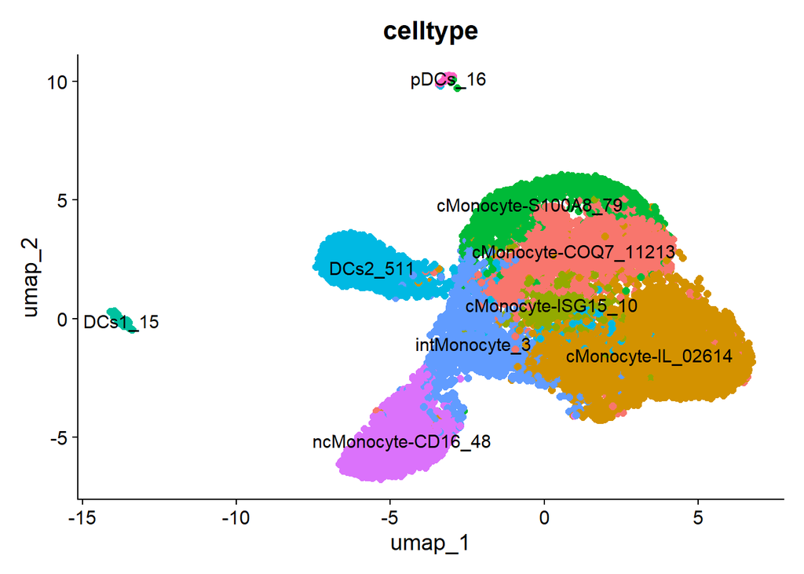

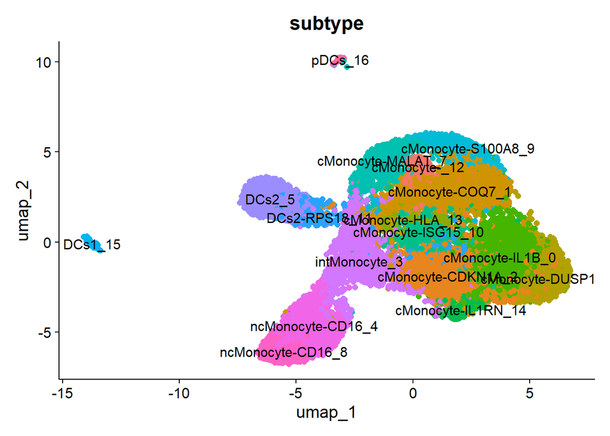

```r
immune.combined@meta.data$subtype <- NA
immune.combined@meta.data$subtype[which(str_detect(immune.combined@meta.data$integrated_snn_res.0.8, "0"))] <- "cMonocyte-IL1B_0"
immune.combined@meta.data$subtype[which(str_detect(immune.combined@meta.data$integrated_snn_res.0.8, "1"))] <- "cMonocyte-COQ7_1"
immune.combined@meta.data$subtype[which(str_detect(immune.combined@meta.data$integrated_snn_res.0.8, "2"))] <- "cMonocyte-CDKN1A_2"
immune.combined@meta.data$subtype[which(str_detect(immune.combined@meta.data$integrated_snn_res.0.8, "3"))] <- "intMonocyte_3"
immune.combined@meta.data$subtype[which(str_detect(immune.combined@meta.data$integrated_snn_res.0.8, "4"))] <- "ncMonocyte-CD16_4"
immune.combined@meta.data$subtype[which(str_detect(immune.combined@meta.data$integrated_snn_res.0.8, "5"))] <- "DCs2_5"
immune.combined@meta.data$subtype[which(str_detect(immune.combined@meta.data$integrated_snn_res.0.8, "6"))] <- "cMonocyte-DUSP1_6"
immune.combined@meta.data$subtype[which(str_detect(immune.combined@meta.data$integrated_snn_res.0.8, "7"))] <- "cMonocyte-MALAT_7"
immune.combined@meta.data$subtype[which(str_detect(immune.combined@meta.data$integrated_snn_res.0.8, "8"))] <- "ncMonocyte-CD16_8"
immune.combined@meta.data$subtype[which(str_detect(immune.combined@meta.data$integrated_snn_res.0.8, "9"))] <- "cMonocyte-S100A8_9"
immune.combined@meta.data$subtype[which(str_detect(immune.combined@meta.data$integrated_snn_res.0.8, "10"))] <- "cMonocyte-ISG15_10"
immune.combined@meta.data$subtype[which(str_detect(immune.combined@meta.data$integrated_snn_res.0.8, "11"))] <- "DCs2-RPS18_11"
immune.combined@meta.data$subtype[which(str_detect(immune.combined@meta.data$integrated_snn_res.0.8, "12"))] <- "cMonocyte-_12"
immune.combined@meta.data$subtype[which(str_detect(immune.combined@meta.data$integrated_snn_res.0.8, "13"))] <- "cMonocyte-HLA_13"
immune.combined@meta.data$subtype[which(str_detect(immune.combined@meta.data$integrated_snn_res.0.8, "14"))] <- "cMonocyte-IL1RN_14"
immune.combined@meta.data$subtype[which(str_detect(immune.combined@meta.data$integrated_snn_res.0.8, "15"))] <- "DCs1_15"
immune.combined@meta.data$subtype[which(str_detect(immune.combined@meta.data$integrated_snn_res.0.8, "16"))] <- "pDCs_16"

##Regrouping cells based on the genes and directions that they shared (upsetplot) and the origin of the cluster (clustree)
immune.combined@meta.data$celltype <- NA
immune.combined@meta.data$celltype[which(str_detect(immune.combined@meta.data$integrated_snn_res.0.8, "0"))] <- "cMonocyte-IL_02614"
immune.combined@meta.data$celltype[which(str_detect(immune.combined@meta.data$integrated_snn_res.0.8, "1"))] <- "cMonocyte-COQ7_11213"
immune.combined@meta.data$celltype[which(str_detect(immune.combined@meta.data$integrated_snn_res.0.8, "2"))] <- "cMonocyte-IL_02614"
immune.combined@meta.data$celltype[which(str_detect(immune.combined@meta.data$integrated_snn_res.0.8, "3"))] <- "intMonocyte_3"
immune.combined@meta.data$celltype[which(str_detect(immune.combined@meta.data$integrated_snn_res.0.8, "4"))] <- "ncMonocyte-CD16_48"
immune.combined@meta.data$celltype[which(str_detect(immune.combined@meta.data$integrated_snn_res.0.8, "5"))] <- "DCs2_511"
immune.combined@meta.data$celltype[which(str_detect(immune.combined@meta.data$integrated_snn_res.0.8, "6"))] <- "cMonocyte-IL_02614"
immune.combined@meta.data$celltype[which(str_detect(immune.combined@meta.data$integrated_snn_res.0.8, "7"))] <- "cMonocyte-S100A8_79"
immune.combined@meta.data$celltype[which(str_detect(immune.combined@meta.data$integrated_snn_res.0.8, "8"))] <- "ncMonocyte-CD16_48"
immune.combined@meta.data$celltype[which(str_detect(immune.combined@meta.data$integrated_snn_res.0.8, "9"))] <- "cMonocyte-S100A8_79"
immune.combined@meta.data$celltype[which(str_detect(immune.combined@meta.data$integrated_snn_res.0.8, "10"))] <- "cMonocyte-ISG15_10"
immune.combined@meta.data$celltype[which(str_detect(immune.combined@meta.data$integrated_snn_res.0.8, "11"))] <- "DCs2_511"
immune.combined@meta.data$celltype[which(str_detect(immune.combined@meta.data$integrated_snn_res.0.8, "12"))] <- "cMonocyte-COQ7_11213"
immune.combined@meta.data$celltype[which(str_detect(immune.combined@meta.data$integrated_snn_res.0.8, "13"))] <- "cMonocyte-COQ7_11213"
immune.combined@meta.data$celltype[which(str_detect(immune.combined@meta.data$integrated_snn_res.0.8, "14"))] <- "cMonocyte-IL_02614"
immune.combined@meta.data$celltype[which(str_detect(immune.combined@meta.data$integrated_snn_res.0.8, "15"))] <- "DCs1_15"
immune.combined@meta.data$celltype[which(str_detect(immune.combined@meta.data$integrated_snn_res.0.8, "16"))] <- "pDCs_16"
```